# IODS course project

#### Creating summary data with mean

```r
ratsl8s <- ratsl %>%
  filter(Time > 0) %>%
  group_by(Group, ID) %>%
  summarise(mean=mean(Weight)) %>%
  ungroup()
glimpse(ratsl8s)
```

```
## Observations: 16
## Variables: 3
## $ Group <fct> 1, 1, 1, 1, 1, 1, 1, 1, 2, 2, 2, 2, 3, 3, 3, 3
## $ ID    <fct> 1, 2, 3, 4, 5, 6, 7, 8, 9, 10, 11, 12, 13, 14, 15, 16
## $ mean  <dbl> 261.0909, 237.6364, 260.1818, 266.5455, 269.4545, 274.72...
```

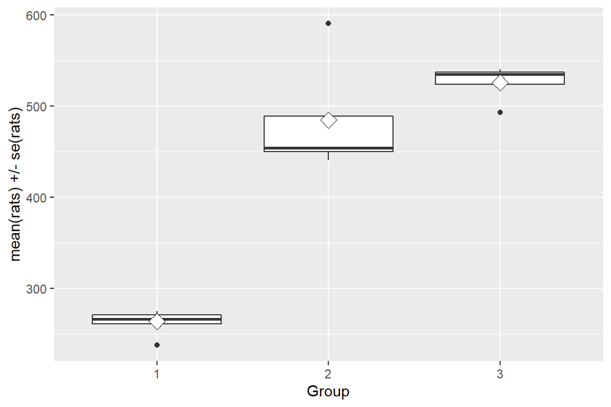

```r
ggplot(ratsl8s, aes(x=Group, y = mean)) + geom_boxplot() + stat_summary(fun.y = "mean", geom = "point", shape=23, size=4, fill = "white") + scale_y_continuous(name = "mean(rats) +/- se(rats)")
```

#### Creating new data by filtering the outlier

```r
glimpse(ratsl8s)
```

```
## Observations: 16
## Variables: 3
## $ Group <fct> 1, 1, 1, 1, 1, 1, 1, 1, 2, 2, 2, 2, 3, 3, 3, 3
## $ ID    <fct> 1, 2, 3, 4, 5, 6, 7, 8, 9, 10, 11, 12, 13, 14, 15, 16
## $ mean  <dbl> 261.0909, 237.6364, 260.1818, 266.5455, 269.4545, 274.72...
```

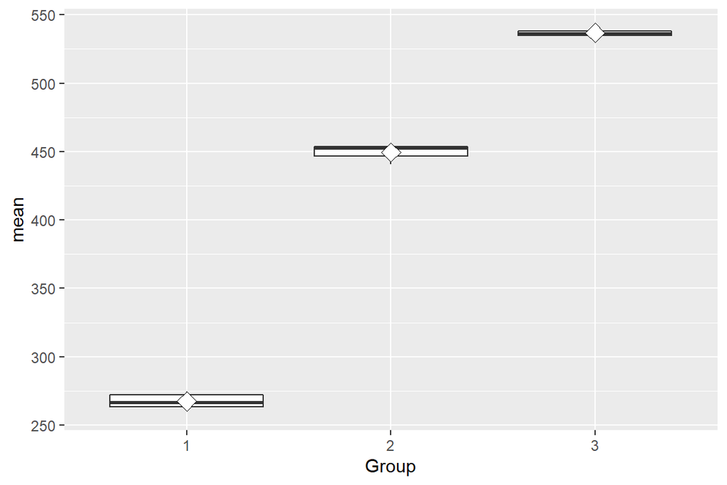

```r
ratsl8s1 <- filter(ratsl8s, Group==1 & mean>250 | Group==2 & mean<550 | Group==3 & mean>500)
ggplot(ratsl8s1, aes(x=Group, y = mean)) + geom_boxplot() + stat_summary(fun.y = "mean", geom = "point", shape=23, size=4, fill = "white")
```

#### Adding baseline and ANOVA test

```r
ratsl8s2 <- ratsl8s %>%
  mutate(baseline = rats$WD1)
fit <- lm(mean ~ baseline + Group, data = ratsl8s2)
summary(fit)
```

```
##
## Call:
## lm(formula = mean ~ baseline + Group, data = ratsl8s2)
##
## Residuals:
##     Min      1Q  Median      3Q     Max
## -21.732  -3.812   1.991   6.889  13.455
##
## Coefficients:
##             Estimate Std. Error t value Pr(>|t|)
## (Intercept) 30.14886   19.88779   1.516   0.1554
## baseline     0.93194    0.07793  11.959 5.02e-08 ***
## Group2      31.68866   17.11189   1.852   0.0888 .
## Group3      21.52296   21.13931   1.018   0.3287
## ---
## Signif. codes:  0 '***' 0.001 '**' 0.01 '*' 0.05 '.' 0.1 ' ' 1
##
## Residual standard error: 10.62 on 12 degrees of freedom
## Multiple R-squared:  0.9947, Adjusted R-squared:  0.9933
## F-statistic: 747.8 on 3 and 12 DF,  p-value: 6.636e-14
```

```r
anova(fit)
```

```
## Analysis of Variance Table
##
## Response: mean
##           Df Sum Sq Mean Sq   F value    Pr(>F)
## baseline   1 252125  252125 2237.0655 5.217e-15 ***
## Group      2    726     363    3.2219   0.07586 .
## Residuals 12   1352     113
## ---
## Signif. codes:  0 '***' 0.001 '**' 0.01 '*' 0.05 '.' 0.1 ' ' 1
```

*The result of the ANOVA test displays that there is no significant difference between groups.*

### Analysis using BPRS

#### Reading BPRS

```r
library(ggplot2)
library(tidyr)
library(dplyr)
bprsl <- read.csv(file = "C:\\Users\\Young Shin\\Documents\\IODS-project\\data\\bprslong.csv", row.names = 1)
```

#### Individuals on the plot

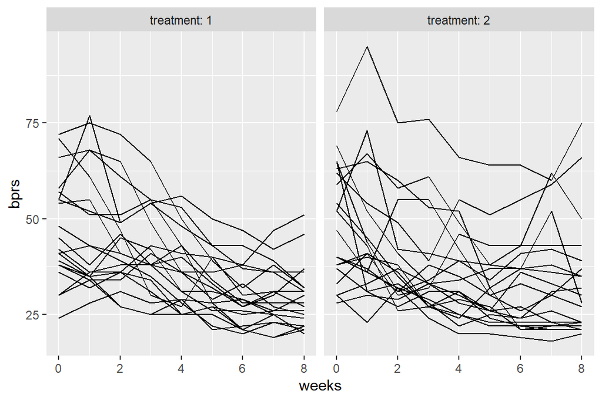

```r
ggplot(bprsl, aes(x = weeks, y = bprs, group = subject)) + geom_line() + facet_grid(. ~ treatment, labeller = label_both)
```

#### Regression model

```r
bprs_reg <- lm(bprs ~ weeks + treatment, data = bprsl)
summary(bprs_reg)
```

```
##
## Call:
## lm(formula = bprs ~ weeks + treatment, data = bprsl)
##
## Residuals:
##     Min      1Q  Median      3Q     Max
## -22.454  -8.965  -3.196   7.002  50.244
##
## Coefficients:
##             Estimate Std. Error t value Pr(>|t|)
## (Intercept)  45.8817     2.2949  19.993   <2e-16 ***
## weeks        -2.2704     0.2524  -8.995   <2e-16 ***
## treatment     0.5722     1.3034   0.439    0.661
## ---
## Signif. codes:  0 '***' 0.001 '**' 0.01 '*' 0.05 '.' 0.1 ' ' 1
##
## Residual standard error: 12.37 on 357 degrees of freedom
## Multiple R-squared:  0.1851, Adjusted R-squared:  0.1806
## F-statistic: 40.55 on 2 and 357 DF,  p-value: < 2.2e-16
```

*The result of regression model above shows that weeks variable have a significantly negative effect on bprs, whereas treatment varable does not.*

#### Random intercept model

```r
library(lme4)
bprs_ref1 <- lmer(bprs ~ weeks + treatment + (1|subject), data = bprsl, REML=FALSE)
summary(bprs_ref1)
```

```
## Linear mixed model fit by maximum likelihood  ['lmerMod']
## Formula: bprs ~ weeks + treatment + (1 | subject)
##    Data: bprsl
##
##      AIC      BIC   logLik deviance df.resid
##   2748.7   2768.1  -1369.4   2738.7      355
##
## Scaled residuals:
##     Min      1Q  Median      3Q     Max
## -3.0481 -0.6749 -0.1361  0.4813  3.4855
##
## Random effects:
##  Groups   Name        Variance Std.Dev.
##  subject  (Intercept)  47.41    6.885
##  Residual             104.21   10.208
## Number of obs: 360, groups:  subject, 20
##
## Fixed effects:
##             Estimate Std. Error t value
## (Intercept)  45.8817     2.4413  18.794
## weeks        -2.2704     0.2084 -10.896
## treatment     0.5722     1.0761   0.532
##
## Correlation of Fixed Effects:
##           (Intr) weeks
## weeks     -0.341
## treatment -0.661  0.000
```

*The result of the random intercetp model above displays that weeks variable significantly affects the dependent variable, but treatment variable does not. According to the estimates of random effects, we can conclude that these intercepts vary by subject, as the standard deviation of the variance appears significantly different from zero.*

#### Random intercetp and random slope model

```r
bprs_ref2 <- lmer(bprs ~ weeks + treatment + (weeks|subject), data = bprsl, REML=FALSE)
summary(bprs_ref2)
```

```
## Linear mixed model fit by maximum likelihood  ['lmerMod']
## Formula: bprs ~ weeks + treatment + (weeks | subject)
##    Data: bprsl
##
##      AIC      BIC   logLik deviance df.resid
##   2745.4   2772.6  -1365.7   2731.4      353
##
## Scaled residuals:
##     Min      1Q  Median      3Q     Max
## -2.8919 -0.6194 -0.0691  0.5531  3.7977
##
## Random effects:
##  Groups   Name        Variance Std.Dev. Corr
##  subject  (Intercept) 64.8222  8.0512
##           weeks        0.9609  0.9803   -0.51
##  Residual             97.4304  9.8707
## Number of obs: 360, groups:  subject, 20
##
## Fixed effects:
##             Estimate Std. Error t value
## (Intercept)  45.8817     2.5685  17.863
## weeks        -2.2704     0.2977  -7.626
## treatment     0.5722     1.0405   0.550
##
## Correlation of Fixed Effects:
##           (Intr) weeks
## weeks     -0.477
## treatment -0.608  0.000
```

#### Random intercetp and random slope model with interaction

```r
bprs_ref3 <- lmer(bprs ~ weeks * treatment + (weeks|subject), data = bprsl, REML=FALSE)
summary(bprs_ref3)
```

```
## Linear mixed model fit by maximum likelihood  ['lmerMod']
## Formula: bprs ~ weeks * treatment + (weeks | subject)
##    Data: bprsl
##
##      AIC      BIC   logLik deviance df.resid
##   2744.3   2775.4  -1364.1   2728.3      352
##
## Scaled residuals:
##     Min      1Q  Median      3Q     Max
## -3.0513 -0.6270 -0.0768  0.5287  3.9259
##
## Random effects:
##  Groups   Name        Variance Std.Dev. Corr
##  subject  (Intercept) 65.0076  8.0627
##           weeks        0.9686  0.9842   -0.51
##  Residual             96.4708  9.8220
## Number of obs: 360, groups:  subject, 20
##
## Fixed effects:
##                 Estimate Std. Error t value
## (Intercept)      50.1767     3.5159  14.271
## weeks            -3.3442     0.6711  -4.983
## treatment        -2.2911     1.9090  -1.200
## weeks:treatment   0.7158     0.4010   1.785
##
## Correlation of Fixed Effects:
##             (Intr) weeks  trtmnt
## weeks       -0.768
## treatment   -0.814  0.753
## weks:trtmnt  0.684 -0.896 -0.840
```

#### ANOVA to compare the two models

```r
anova(bprs_ref2, bprs_ref3)
```

```
## Data: bprsl
## Models:
## bprs_ref2: bprs ~ weeks + treatment + (weeks | subject)
## bprs_ref3: bprs ~ weeks * treatment + (weeks | subject)
##           Df    AIC    BIC  logLik deviance  Chisq Chi Df Pr(>Chisq)
## bprs_ref2  7 2745.4 2772.6 -1365.7   2731.4
## bprs_ref3  8 2744.3 2775.4 -1364.1   2728.3 3.1712      1    0.07495 .
## ---
## Signif. codes:  0 '***' 0.001 '**' 0.01 '*' 0.05 '.' 0.1 ' ' 1
```

*The result of ANOVA demonstrates that the model including interaction does not fit significantly better than the random intercept and random slope model.*